# DATA301 Assignment 4

Exercise 1 & 2

Hannah Young, 300662592

2026-09-24

## Exercise 1:

Imagine that you are studying the time between successive arrivals of customers at a service desk. You collect data, the times between arrivals, and decide that an exponential distribution is a reasonable model for these observations.

#### (a). There are several ways of computing order statistics, e.g., the quartiles that you need for $\hat{\lambda}_{IQR}$(X). Read and summarise the analysis of alternatives made by Wicklin (2017). Which type of order statistics would you use and why? Which is the default type of order statistics your version of R/Python uses?

*I could only find this blog post by Rick Wicklin about Sample quantiles: A comparison of 9 definitions: https://blogs.sas.com/content/iml/2017/05/24/definitions-sample-quantiles.html*

The article explores the different definitions of sample quantiles that commonly appear in statistical software packages, originally defined by Hyndman and Fan in 1996.

Wicklin gives a general formula for calculating quantile estimates as $q - (1 - \lambda) x_j + \lambda x_{j+1}$, where $\lambda$ and j depend on the values of p, n and a method-specific parameter m. These are used to estimate the $p_{th}$ quantile for a population with a sample of N observations that are sorted so that $x_1 \leq x_2 \leq ... \leq x_N$.

There are nine different types of sample quantiles, with the default type used in R/Python being type = 7. This calculates the parameter m with $1 - p$.

#### (b). You suspect that $\hat{\lambda}_{IQR}$ is biased, so derive and implement a first-order bootstrap bias corrected estimator based on $\hat{\lambda}_{IQR}$. Denote it $\tilde{\lambda}$. You may fix the number of bootstrap replications in B = 200 for every input sample.

A first order bias corrected estimator simulates a leading residual bias of order term and subtracts it from the original estimate to improve accuracy.  
Bias corrected estimator = biased estimator - bootstrap estimator.

$$\tilde{\lambda} = \hat{\lambda}_{IQR} -
\hat{BIAS}_{bootstrap}$$

$$= \hat{\lambda}_{IQR} -
(\lambda_{bootstrap} - \hat{\lambda}_{IQR})$$

$$= \hat{\lambda}_{IQR} -
\lambda_{bootstrap} + \hat{\lambda}_{IQR}$$

$$= 2\hat{\lambda}_{IQR} -
\lambda_{bootstrap}$$

```r
set.seed(301)
B = 200

quant1 <- quantile(x, 0.25)
quant3 <- quantile(x, 0.75)
lambda_hat <- log(3) / (quant3 - quant1)

#doing a bootstrap
lambda_boot <- numeric(B)

for (b in 1:B){
  x_boot <- sample(x, size = length(x), replace = TRUE)
  quant1_boot <- quantile(x_boot, 0.25)
  quant3_boot <- quantile(x_boot, 0.75)
  lambda_boot[b] <- log(3) / (quant3_boot - quant1_boot)
}

lambda_bar_boot <- mean(lambda_boot)

lambda_tilde <- 2 * lambda_hat - lambda_bar_boot
```

## Exercise 2:

Consider the ausbeer data from the fpp2 R package: quarterly beer production in Australia. This is an ordered, discrete time series. The order of the data matters, as it is recorded yearly in quarters and is equally spaced.

| Min. | 1st Qu. | Median | Mean | 3rd Qu. | Max. |
| --- | --- | --- | --- | --- | --- |
| 213 | 379.2 | 422 | 415.4 | 465.8 | 599 |

#### 1. What is the frequency of the series? How can you determine this from the data and/or the time-series plot?

The frequency is four. Data was collected four times every year from 1956 to 2010 in each quarter. We can see this in the data, where each year has four corresponding columns. There is some missing data for specific quarters, such as 2006 missing data from Q1 and Q2, alongside data for 2010 only being collected up to Q2.

|  | Q1 | Q2 | Q3 | Q4 |
| --- | --- | --- | --- | --- |
| **1956** | 284 | 213 | 227 | 308 |
| **1957** | 262 | 228 | 236 | 320 |
| **1958** | 272 | 233 | 237 | 313 |
| **1959** | 261 | 227 | 250 | 314 |

|  | Q1 | Q2 | Q3 | Q4 |
| --- | --- | --- | --- | --- |
| **2006** | NA | NA | 405 | 491 |
| **2007** | 427 | 383 | 394 | 473 |
| **2008** | 420 | 390 | 410 | 488 |
| **2009** | 415 | 398 | 419 | 488 |
| **2010** | 414 | 374 | NA | NA |

#### 2. Describe the overall behavior of the series. Is there evidence of a long-term trend?

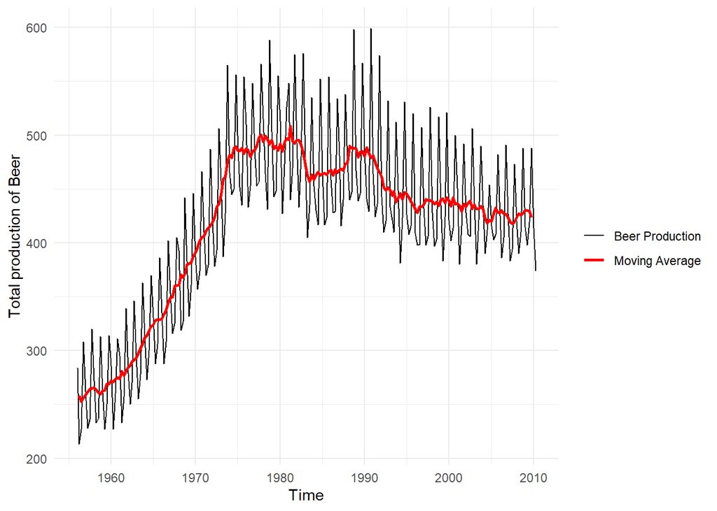

#### 3. Is there evidence of seasonality? If so, describe the seasonal pattern.

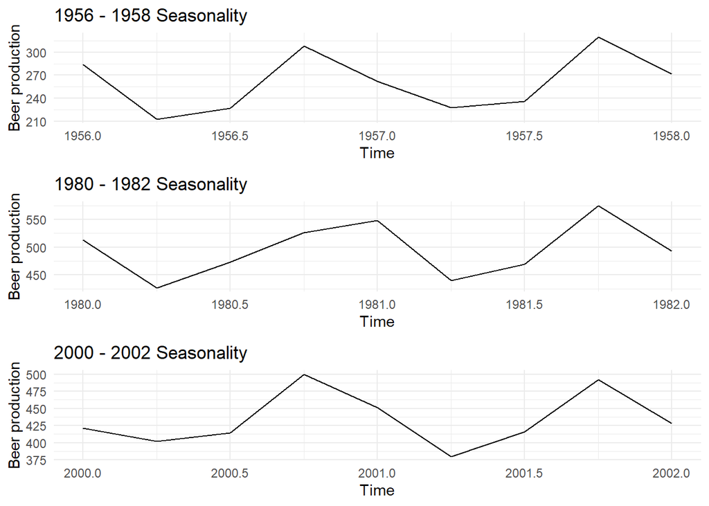

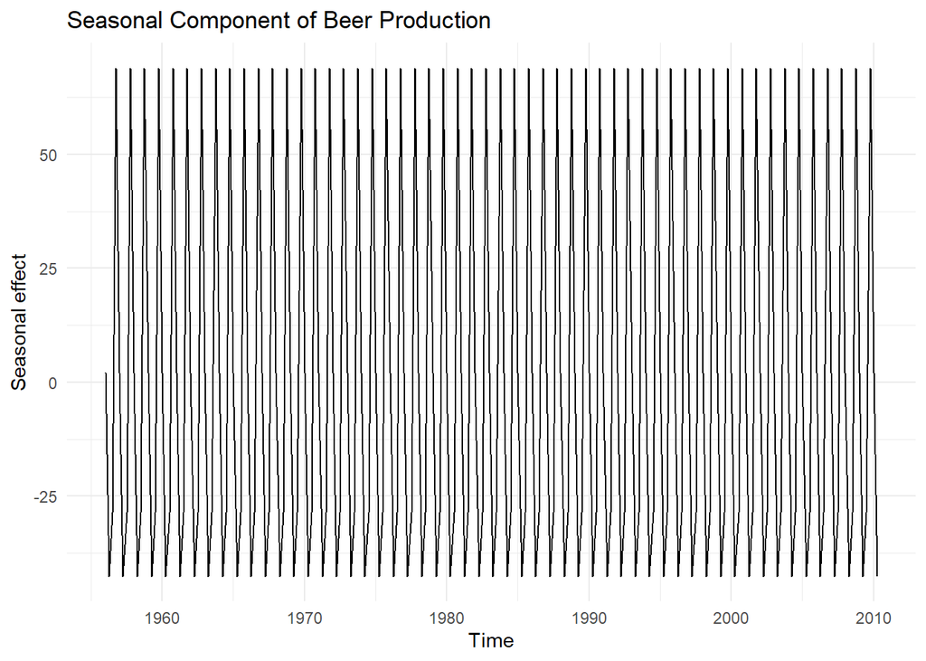

There is evidence of seasonality, similar spikes in beer production appearing throughout the years. Taking 2-year snapshots at random spots in the timeline, we can see that it follows a re-occurring up and down pattern throughout the years. While the exact values are not consistent, the shape stays around the same. The largest spike in beer production occurs in quarter 4, which then decreases throughout the following year until spiking back up again in quarter 4.

Taking a look at the seasonal graph for the entire series, this pattern repeats consistently for the entire time period providing evidence towards strong seasonality for the data.

#### 4. Does the variability appear constant over time? Explain what you see in the plot and whether a transformation might be appropriate.

For determining constant variability we want to look at the size of the fluctuations in number of beers produced. Looking back at the first plot showing the overall behavior of the series, when beer production was relatively low through 1950 to ~1975 the fluctuations are smaller and more constant in size. When the production reached its peak and averaged around 500 beers through the 1980’s to 1995 we can see greater fluctuations around the trend become bigger and irregular. In the more recent years when the number of beers produced decreases, the size of the fluctuations appear to decrease slightly as-well.

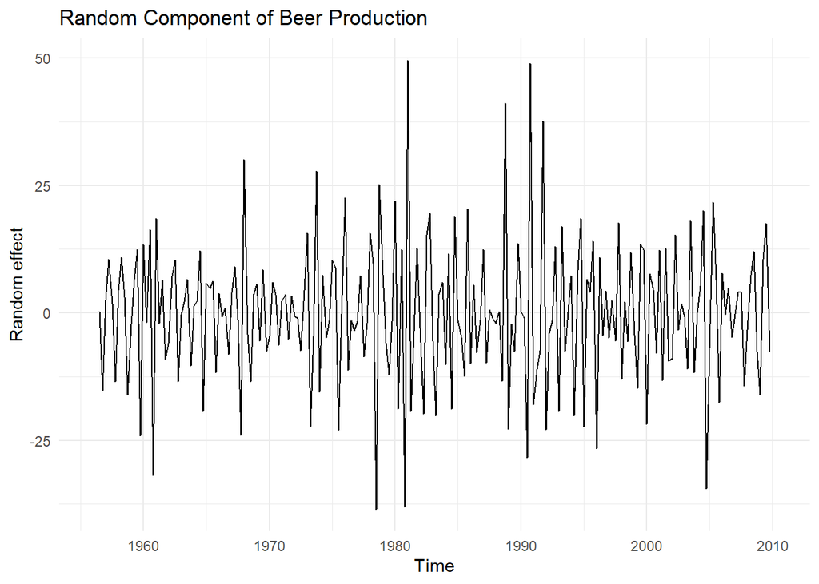

The decomposition plot of irregular noise in the data shows this slightly as-well, with the large spikes in the data being within the same time period as the greater fluctuations.

This all suggests that the variability of the data does not stay completely constant over time. A transformation might be appropriate if the variability of the data is actually increasing with the level of the series, instead of being random. This would help stabilize the variance as we aim for equal variance (homoscedasticity) across a data set.

#### 5. Are there any observations that you would regard as unusual? Identify them and explain why they attract attention.

Looking back at the decomposition plot, there six observations that stand out as distinct spikes in the data and appear to be unusual.

There are large positive and negative deviations from 1977 to 1993 that appear to be significantly further from 0. To identify them, I used the constraint of random values greater than 35. The random component represents the aspect of beer production that isn’t already explained by estimated trend or seasonality. This is useful for identifying unusual observations because large/small remainder values indicate an observation that was different from what would be expected based on the current trend and seasonality for that time.

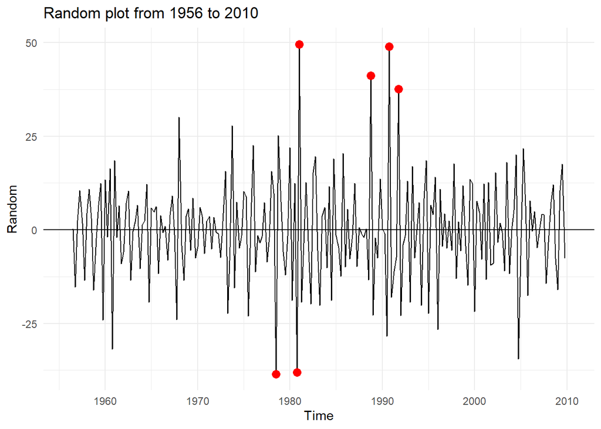

| Year | Quarter | BeerProduced | Remainder |
| --- | --- | --- | --- |
| 1978 | 3 | 431 | -38.49 |
| 1980 | 4 | 526 | -38.02 |
| 1981 | 1 | 548 | 49.62 |
| 1988 | 4 | 598 | 41.23 |
| 1990 | 4 | 599 | 48.98 |
| 1991 | 4 | 574 | 37.61 |

#### 6. Plot the series by season (for example, using a seasonal plot). What does this reveal that is less obvious in the ordinary time-series plot?

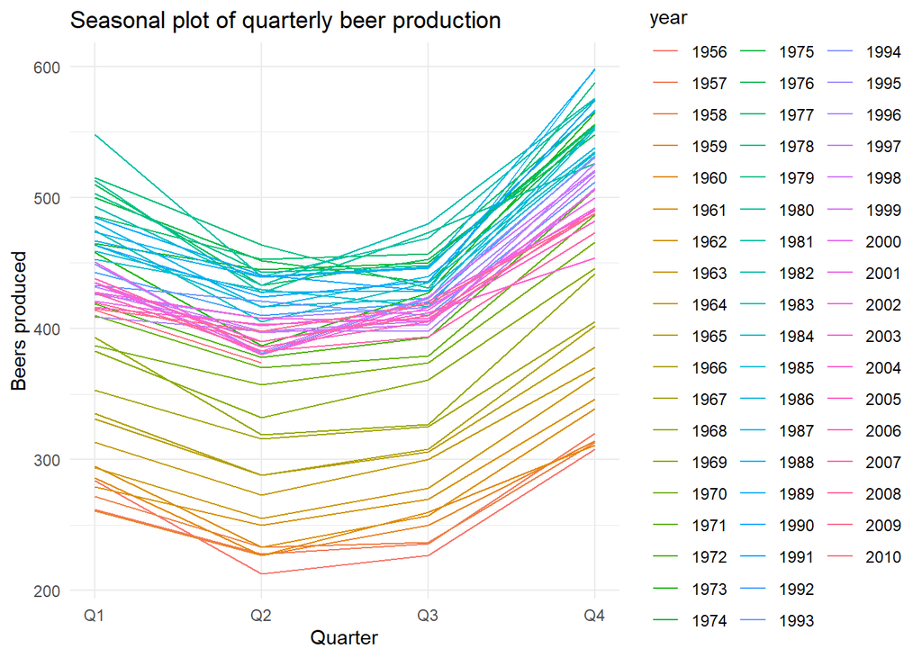

The season plot of the four quarters give a good visualization of the shape the data follows compared to the ordinary time-series plot. We can see the curve that the data follows from quarter 1 to quarter 4. Because there are alot of recorded years in this time series identifying individual dates is slightly difficult but it displays the trend that was observed earlier; the number of beers produced per year increased until around the 1980’s, then started to slightly decrease.

#### 7. Plot the seasonal subseries. Which quarters have the highest and lowest typical values? Is the seasonal pattern stable over time?

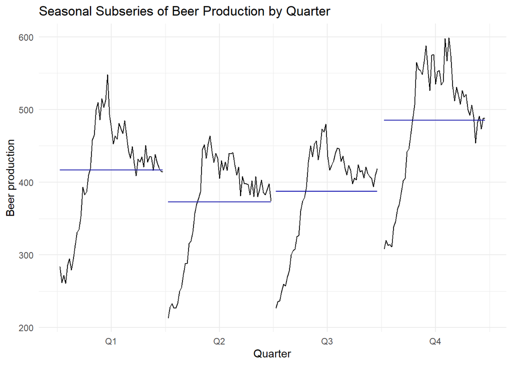

The seasonal subseries plot shows that quarter 4 has the highest typical value of beer production, and quarter 2 has the lowest. Quarter 1 and quarter 3 have typical values between these, with the final ranking from highest to lowest being; quarter 4, quarter 1, quarter 3 and quarter 2.

The seasonal pattern appears to be relatively stable over time because the ordering of the quarters typical values is visible throughout the dataset (like in the seasonal plot). Although the overall production amount of beer changes over time, the seasonal pattern remains constant.

#### 8. Would you detrend or transform the series before modelling it? Give a visual argument for your answer. Do not fit a model.

I would consider de-trending the series to improve its stationarity. The time series shows an increasing and decreasing long-term trend in beer production which tells us the mean level of the series changes over time. The variance also does not remain constant over time, with specific periods having greater fluctuation than others. De-trending the series before modelling could help improve the accuracy and quality of results because the mean and variance wont be impacted by long-term trends.

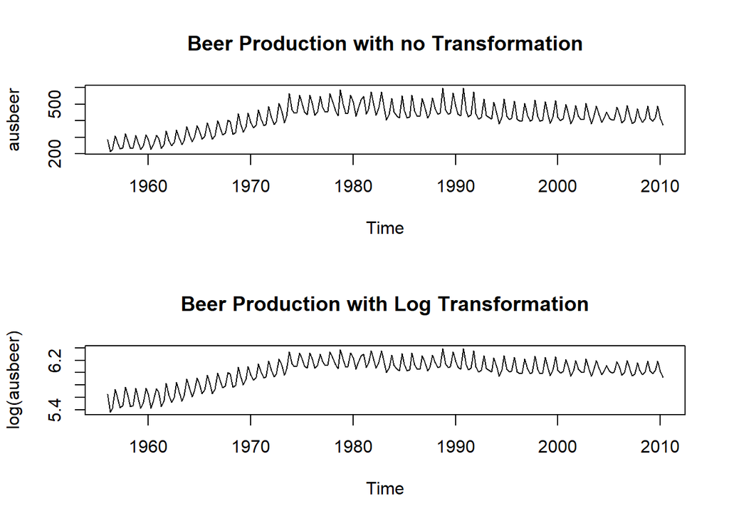

Another method to improve the variance would be to transform the series with a log transformation. This stabilizes the variance by compressing larger values more than smaller ones, reducing the heteroscedasticity of the data. While we can see in the visualization that the previously noted areas of greater variance (~1990’s) have been almost “smushed down”, the general shape of the data has not changed significantly. This could be because the existing variance of the data is not scaled proportionally with the mean so applying the log transformation does not greatly improve the variance.

Since de-trending and transforming can both be applied to a time series I would recommend de-trending the series first to see if that improves the shape of the mean and variance, then transform with a log transformation if it would add some meaningful benefit when going on to model the data.